# R for Absolute Beginners | Recap

R Basic Syntax

Authors: Isabel Duarte & Ramiro Magno

October/November 2023

# Introduction

This recap version of the *“R for Absolute Beginners”* course is aimed at making sure that all participants in the course *“R-mind”* know R in order to properly follow the course.

### Installing R and RStudio

1. First **install R** from https://cran.r-project.org/mirrors.html Choose any CRAN mirror (for example: https://cloud.r-project.org/bin/windows/) to download R for your platform (Windows), and install it.
2. After installing R, you can **download and install RStudio** from: https://posit.co/download/rstudio-desktop/

### Self-learning tutorials

To help you learn the basics of R, we provide **3 options**. Choose the one that you like the most (one alternative in each tab bellow):

- **A.** Install the **self-learning package `swirl`**, and follow the tutorial instructions with short explanations given at the R console. This is the **option that we suggest** (good coverage of basic R - for absolute beginners);
- **B.** Follow the detailed **hands-on protocol** (the most exhaustive option - for beginners, but requires more time);
- **C.** If you know and have experience with R, you can complete a **brief self-evaluation exam** to check if you meet the basic required skills. For this, you just need to install the package `ualg.compbio` which contains a self-evaluation exam containing a few simple exercises to make sure you have the R basics required for the course (for R users with basic experience).

Now, just *Keep Calm… and Good Work!*

## **A. Using the *swirl* package tutorial**

The `swirl` package is an **interactive, self-paced, hands-on tutorial**. You will *learn R inside R*. For more info about this package, visit: https://swirlstats.com/

### RStudio

To start open RStudio. This is an Integrated Development Environment - **IDE** - that includes syntax-highlighting **text editor** (1 in Figure1), an **R console** to execute code (2 in Figure1), as well as **workspace** and **history** management (3 in Figure1), and tools for **plotting** and **exporting** images, **browsing** the workspace, managing **packages** and **viewing** html/pdf files created within RStudio (4 in Figure1).

[figure not shown]

Figure 1: RStudio Graphical User Interface (GUI)

### **Install the *swirl* package & Follow the guided course**

Type these instructions in the R console (panel 2 in Figure 1).

The words after a `#` sign are called comments, and are not interpreted by R, so you do not need to copy them.  
You can copy-paste the code, and press enter after each command.

```r
install.packages("swirl")   # Install swirl

library("swirl")            # Load the swirl package to make it available for you to use

swirl()                     # Start swirl
```

After starting `swirl`, follow the instructions given by the program, and complete all of the following lessons:

**Please install the course:**  
1: R Programming: The basics of programming in R

**Choose the course:**  
1: R Programming

**Complete the following lessons, in this order:**  
1: Basic Building Blocks  
2: Workspace and Files  
3: Sequences of Numbers  
4: Vectors  
5: Missing Values  
6: Subsetting Vectors  
7: Matrices and Data Frames  
8: Logic  
9: Functions  
12: Looking at Data  
15: Base Graphics

Now, just *Keep Calm… and Good Work!*

#### **Review & Extra notes about R and RStudio**

After finishing the introduction to R with `swirl`, please recall the following information and hints about R and R programming.

1. R is case sensitive - be aware of capital letters (**b** is different from **B**).
2. All R code lines starting with the **#** (hash) sign are interpreted as comments, and therefore not evaluated.

```r
# This is a comment
# 3 + 4   # this code is not evaluated, so and it does not print any result
2 + 3     # the code before the hash sign is evaluated, so it prints the result (value 5)
```

```
[1] 5
```

3. Expressions in R are evaluated from the innermost parenthesis toward the outermost one (following proper mathematical rules).

```r
# Example with parenthesis:
((2+2)/2)-2
```

```
[1] 0
```

```r
# Without parenthesis:
2+2/2-2
```

```
[1] 1
```

4. Spaces in variable names are not allowed — use a dot `.` or underscore `_` to create longer names to make the variables more descriptive, e.g. `my.variable_name`.
5. Spaces between variables and operators do not matter: `3+2` is the same as `3 + 2`, and `function (arg1 , arg2)` is the same as `function(arg1,arg2)`.
6. A new line (enter) ends one command in R. If you want to write 2 expressions/commands in the same line, you have to separate them by a `;` (semi-colon).

```r
#Example:
3 + 2 ; 5 + 1
```

```
[1] 5
```

```
[1] 6
```

7. To access the help pages on R functions, just type `help(function_name)` or `?function_name`.

```r
# Example: open the documentation about the function sum
help (sum)
# Quick access to help page about sum
?sum
```

8. RStudio **auto-completes** your commands by showing you possible alternatives as soon as you type 3 consecutive characters. If you want to see the options for less than 3 chars to get help on available functions, just press tab to display available options. **Tip: Use auto-complete as much as possible to avoid typing mistakes.**
9. There are 4 main vector **data types** in R: **Logical** (TRUE or FALSE); **Numeric** (e.g. 1,2,3…); **Character** (i.e. text, for example “u”, “alg”, “arve”) and **Complex** (e.g. 3+2i).
10. Vectors are ordered sets of elements. In R vectors are **1-based**, i.e. the first index position is number 1 (as opposed to other programming languages whose indexes start at zero, like Python).
11. R objects can be divided in two main groups: **Functions** and **Data-related objects**. Functions receive arguments inside circular brackets `( )` and objects receive arguments inside square brackets `[ ]`:

    `function (arguments)`  
    `data.object [arguments]`
12. There are **five basic data structures** in R: `Vector`, `Matrix`, `Array`, `Data frame`, and `List` (see following figure):

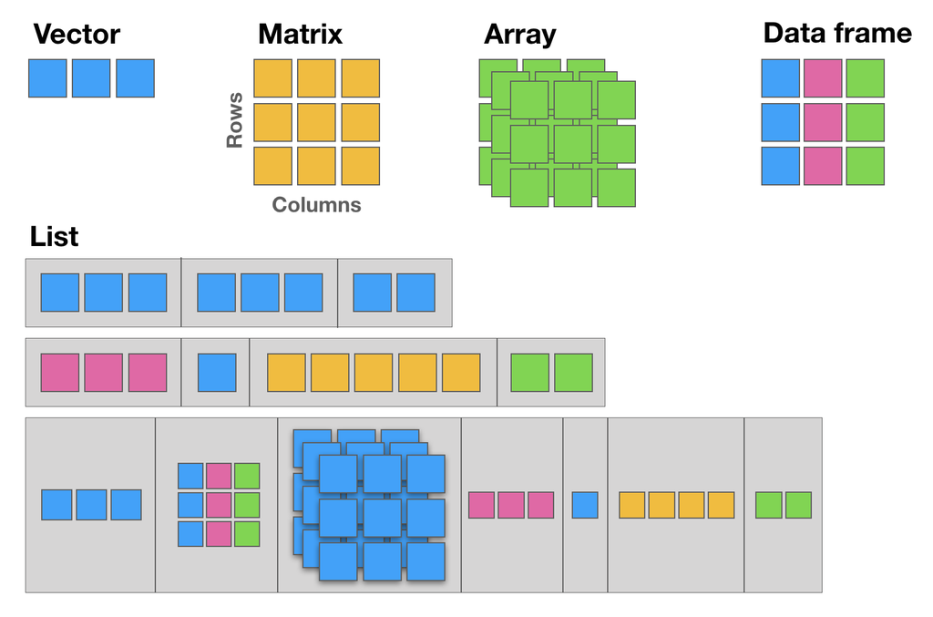

12.1 The basic data structure in R is the **vector**, which requires all of its elements to be of the same type (e.g. all *numeric*; all *character* (text); all *logical* (`TRUE` or `FALSE`)).

12.2 **Matrices** are two dimensional vectors (tables), where *all columns are of the same length*, and all from the same type.

12.3 **Data frames** are the most flexible and commonly used R data structures, used to store datasets in spreadsheet-like tables. The columns can be vectors of different types (i.e. text, number, logical, etc, can all be stored in the same data frame), but each column must to be of the same data type.

12.4 **Lists** are ordered sets of elements, that can be arbitrary R objects (vectors, data frames, matrices, strings, functions, other lists etc), and heterogeneous, i.e. each element can be of a different type and different lengths.

13. R is column-major by default, meaning that the elements of a multi-dimensional array are linearly stored in memory column-wise. This is important for example when using data to populate a `matrix`.

```r
matrix(1:9, ncol = 3)
```

```
     [,1] [,2] [,3]
[1,]    1    4    7
[2,]    2    5    8
[3,]    3    6    9
```

14. When subsetting matrices and data-frames, the first index is the row, and the second index is the column. If left empty (no value), then the full row or the full column is returned.

```r
# My letters matrix
(my_letters <- matrix(rep(LETTERS[1:3], each=3), ncol = 3))
```

```
     [,1] [,2] [,3]
[1,] "A"  "B"  "C"
[2,] "A"  "B"  "C"
[3,] "A"  "B"  "C"
```

```r
# Element in Row 1, Column 2
my_letters[1,2]
```

```
[1] "B"
```

```r
# Element in Row 2, Column 3
my_letters[2,3]
```

```
[1] "C"
```

```r
# Row 3
my_letters[3,]
```

```
[1] "A" "B" "C"
```

```r
# Column 1
my_letters[,1]
```

```
[1] "A" "A" "A"
```

##### **Working directory**

The working directory is the location in the filesystem (folder) where R will look for input data and where it will save the output from your analysis. In RStudio you can graphically check this information.

```r
dir()   # list all files in your working directory
getwd() # find out the path to your working directory
setwd("/home/isabel") # example of setting a new working directory path
```

##### **Saving your workspace in R**

The R environment is controlled by hidden files (files that start with a dot `.`) in the start-up directory: `.RData`, `.Rhistory` and `.Rprofile` (optional).

- **.RData** is a file containing all the objects, data, and functions created during a work-session. This file can then be loaded for future work without requiring the re-computation of the analysis. (Note: it can potentially be a very large file);
- **.Rhistory** saves all commands that have been typed during the R session;
- **.Rprofile** useful for advanced users to customize RStudio behavior.

These files can be renamed:

```r
# DO NOT RUN
save.image (file=“myProjectName.RData”)
savehistory (file=“myProjectName.Rhistory”)
```

To quit R just close RStudio, or use the `q ()` function. You will then be asked if you want to save the workspace image (i.e. the `.RData` file):

```r
q()
```

`Save workspace image to ~/path/to/your/working/directory/.RData? [y/n/c]:`

If you type `y` (yes), then the entire R workspace will be written to the `.RData` file (which can be very large). Often it is sufficient to just save an analysis script (i.e. a reproducible protocol) in an R source file. This way, one can quickly regenerate all data sets and objects for future analysis. **The `.RData` file is particularly useful to save the results from analyses that require a long time to compute.**  
In RStudio, to quit your session, just hit the close button (x button), just like when you want to quit any other application in your computer.  
In RStudio Server, you must log out of your account. When you log back in, your session will resume.

##### **Package repositories**

In R, the fundamental unit of shareable code is the **package**. A package bundles together code, data, documentation, and tests, and is easy to share with others. These packages are stored in online repositories from which they can be easily retrieved and installed on your computer ([R packages](http://r-pkgs.had.co.nz/) by Hadley Wickham). There are 2 main R repositories:

- [The Comprehensive R Archive Network - CRAN](https://cran.r-project.org/) (18927 packages in March 2022)
- [Bioconductor](https://www.bioconductor.org/) (2083 packages in March 2022) (bioscience data analysis)

This huge variety of packages is one of the reasons why R is so successful: the chances are that someone has already developed a method to solved the problem that you’re working on, and you can benefit from their work by downloading their package for free.

In this course, we will not use many packages. However, if you continue to use R for your data analyses you will need to install many more useful packages, particularly from Bioconductor — *an open source, open development software project to provide tools for the analysis and comprehension of high-throughput genomics data […] based primarily on the R programming language.*

##### **How to Install and Load packages**

There are several alternative ways to install packages in R. Depending on the repository from which you want to install a package, there are dedicated functions that facilitate this task:

- `install.packages()` built-in function to install packages from the CRAN repository;
- `BiocManager::install()` to install packages from the Bioconductor repository;
- `remotes::install_github` to install packages from GitHub (a code repository, not exclusively dedicated to R).

After installing a package, you must load it to make its contents (functions and/or data) available. The loading is done with the function `library()`. Alternatively, you can prepend the name of the package followed by `::` to the function name to use it (e.g. `ggplot2::qplot()`).

```r
install.packages("ggplot2")   # install the package called ggplot2 from CRAN
library ("ggplot2")            # load the library ggplot2

help (package=ggplot2)         # help(package="package_name") to get help about a specific package
vignette ("ggplot2")           # show a pdf with the package manual (called R vignettes)
```

##### **Creating an RStudio project**

RStudio Projects are a great functionality, easing the transition between dataset analyses, and allowing a fast navigation to your analysis/working directory. To create a new project:

```
File > New Project... > New Directory > New Project
Directory name: compBiol_module1
Create project as a subdirectory of: ~/
                           Browse... (directory/folder to save the class data)
Create Project
```

Projects should be personalized by clicking on the menu in the right upper corner. The general options - **R General** - are the most important to customize, since they allow the definition of the RStudio “behavior” when the project is opened. The following suggestions are particularly useful:

```
Restore .RData at startup - Yes (for analyses with +1GB of data, you should choose "No")
Save .RData on exit - Ask
Always save history - Yes
```

[figure not shown]

Figure 2: Customize Project

## **B. Hands-on tutorial**

This mini hands-on tutorial serves as an introduction to basic R, covering the following topics:

- Online sources of information about R;
- Packages, Documentation and Help;
- Basics and syntax of R;
- Main R data structures: Vectors, Matrices, Data frames, Lists, and Factors;
- Brief intro to R control-flow via Loops and Conditionals;
- Brief description of function declaration;
- Listing of some of the most commonly used built-in functions in R.

#### Tutorial organization

This protocol is divided into **7 parts**, each one identified by a **Title**, **Maximum execution time** (in parenthesis), a brief **Task description** and the **R commands** to be executed. These will always be inside grey text boxes, with the font colored according to the R syntax highlighting.

#### Online sources and other useful Bibliography

- **Websites**
  - [R Project](http://www.r-project.org) (The developers of R)
  - [Quick-R](http://www.statmethods.net) (Roadmap and R code to quickly use R)
  - [Cookbook for R](http://www.cookbook-r.com) (R code “recipes”)
  - [Bioconductor workflows](http://bioconductor.org/packages/release/BiocViews.html#___Workflow) (R code for pipelines of genomic analyses)
  - [Introduction to Data Science](https://rafalab.github.io/dsbook/) (Free online book from Rafael A. Irizarry, 2020)
  - [Advanced R](http://adv-r.had.co.nz/) (If you want to learn R from a programmers perspective)
- **Books**
  - Introductory Statistics with R (*Springer*, Dalgaard, 2008)
  - A first course in statistical programming with R (*CUP*, Braun and Murdoch, 2016)
  - Computational Genome Analysis: An Introduction (*Springer*, Deonier, Tavaré and Waterman, 2005)
  - R programming for Bioinformatics (*CRC Press*, Gentleman, 2008)
  - R for Data Science: Import, Tidy, Transform, Visualize, and Model Data (*O’Reilly*, Wickham and Grolemund, 2017) (for advanced users)

### Basics

#### General notes (about R and RStudio)

1. R is case sensitive - be aware of capital letters (**b** is different from **B**).
2. All R code lines starting with the **#** (hash) sign are interpreted as comments, and therefore not evaluated.

```r
# This is a comment
# 3 + 4   # this code is not evaluated, so and it does not print any result
2 + 3     # the code before the hash sign is evaluated, so it prints the result (value 5)
```

```
[1] 5
```

3. Expressions in R are evaluated from the innermost parenthesis toward the outermost one (following proper mathematical rules).

```r
# Example with parenthesis:
((2+2)/2)-2
```

```
[1] 0
```

```r
# Without parenthesis:
2+2/2-2
```

```
[1] 1
```

4. Spaces matter in variable names — use a dot or underscore to create longer names to make the variables more descriptive, e.g. `my.variable_name`.
5. Spaces between variables and operators do not matter: `3+2` is the same as `3 + 2`, and `function (arg1 , arg2)` is the same as `function(arg1,arg2)`.
6. If you want to write 2 expressions/commands in the same line, you have to separate them by a `;` (semi-colon)

```r
#Example:
3 + 2 ; 5 + 1
```

```
[1] 5
```

```
[1] 6
```

7. More recent versions of RStudio **auto-complete** your commands by showing you possible alternatives as soon as you type 3 consecutive characters, however, if you want to see the options for less than 3 chars, just press tab to display available options. **Tip: Use auto-complete as much as possible to avoid typing mistakes.**
8. There are 4 main vector **data types**: **Logical** (TRUE or FALSE); **Numeric** (e.g. 1,2,3…); **Character** (e.g. “u”, “alg”, “arve”) and **Complex** (e.g. 3+2i)
9. Vectors are ordered sets of elements. In R vectors are **1-based**, i.e. the first index position is number 1 (as opposed to other programming languages whose indexes start at zero).
10. R objects can be divided in two main groups: **Functions** and **Data-related objects**. Functions receive arguments inside circular brackets `( )` and objects receive arguments inside square brackets `[ ]`:

    `function (arguments)`  
    `data.object [arguments]`

#### Start/Quit RStudio

RStudio can be opened by double-clicking its icon.

The R environment is controlled by hidden files (files that start with a **.**) in the start-up directory: `.RData`, `.Rhistory` and `.Rprofile` (optional).

- **.RData** is a file containing all the objects, data, and functions created during a work-session. This file can then be loaded for future work without requiring the re-computation of the analysis. (Note: it can potentially be a very large file);
- **.Rhistory** saves all commands that have been typed during the R session;
- **.Rprofile** useful for advanced users to customize RStudio behavior.

It is always good practice to rename these files:

```r
# DO NOT RUN
save.image (file=“myProjectName.RData”)
savehistory (file=“myProjectName.Rhistory”)
```

To quit R, just close RStudio or use the `q ()` function, and you will be asked if you want to save the workspace image (i.e. the `.RData` file):

```r
q()
```

```
Save workspace image to ~/path/to/your/working/directory/.RData? [y/n/c]:
```

By typing `y` (yes), then the entire R workspace will be written to the `.RData` file (which can be very large). Often it is sufficient to just save an analysis script (i.e. a reproducible protocol) in an R source file. This way, one can quickly regenerate all data sets and objects for future analysis. The .RData file is particularly useful to save the results from analyses that require a long time to compute, and to keep checkpoints of your analysis pipeline.

#### Package repositories

In R, the fundamental unit of shareable code is the **package**. A package bundles together code, data, documentation, and tests, and is easy to share with others. These packages are stored online from which they can be easily retrieved and installed on your computer ([R packages](http://r-pkgs.had.co.nz/) by Hadley Wickham). There are 2 main R repositories:

- [The Comprehensive R Archive Network - CRAN](https://cran.r-project.org/) (14297 packages in May2019)
- [Bioconductor](https://www.bioconductor.org/) (1741 packages in May 2019) (bioscience data analysis)

This huge variety of packages is one of the reasons why R is so successful: the chances are that someone has already solved a problem that you’re working on, and you can benefit from their work by downloading their package for free.

#### Installing packages

**In this tutorial you will not use any packages.** However, if you continue to use R for biodata analysis you will surely need to install many useful packages, both from CRAN and from Bioconductor (R repositories), and from other code repositories such as GitHub.

##### **How to Install and Load packages**

There are several alternative ways to install packages in R. Depending on the repository from which you want to install a package, there are dedicated functions that facilitate this task:

- `install.packages()` built-in function to install packages from the CRAN repository;
- `BiocManager::install()` to install packages from the Bioconductor repository;
- `remotes::install_github` to install packages from GitHub (a code repository, not exclusively dedicated to R).

After installing a package, you must load it to make its contents (functions and/or data) available. The loading is done with the function `library()`. Alternatively, you can prepend the name of the package followed by `::` to the function name to use it (e.g. `ggplot2::qplot()`).

First lets learn how to **install packages from CRAN and from Bioconductor**. To install packages from CRAN, R provides the `install.packages()` function, and any installed package, to be used, must be loaded via the `library()` function.

```r
# install the package called ggplot2
install.packages ("ggplot2")

# load the library ggplot2
library ("ggplot2")
```

To install packages from Bioconductor, you must first install Bioconductor:

```r
if (!requireNamespace("BiocManager", quietly = TRUE))
    install.packages("BiocManager")
BiocManager::install()
```

Once installed, you can now download packages from Bioconductor using the `BiocManager::install()` function. The package `AnnotationDbi` is one of the most used in the context of genomics. Lets install it as an example of how to install packages from the Bioconductor repository:

```r
# Install the package
BiocManager::install("AnnotationDbi")

# Load the package
library("AnnotationDbi")
```

Now the functions provided by the `ggplot2` and the `AnnotationDbi` packages are available to be used in R.

To install packages from GitHub, the easiest way is to install the `remotes` package first, and then install the package of interest.

```r
# Make sure you have the {remotes} installed:
install.packages('remotes')

# Now you can install the ualg.compbio package from GitHub with:
remotes::install_github("instructr/ualg.compbio")
```

Now you will have the tutorials provided by the `ualg.compbio` package.

#### Getting help

But how to get information/help on how to use any function in R? There are many built-in ways in which R can provide help regarding its functions and packages:

```r
# help(package="package_name") to get help about a specific package
help (package=ggplot2)

# show a pdf with the package manual (called R vignettes)
vignette ("ggplot2")

# ?function to get quick info about the function of interest
?qplot
```

#### Working environment

Your working environment is the place where the variables, functions, and data that you create are stored. More advanced users can create more than one environment.

```r
ls()    # list all objects in your environment
dir()   # list all files in your working directory
getwd() # find out the path to your working directory
setwd("/home/foo/bar/DATA/") # example of setting a new working directory path
```

### Hands-on tutorial

#### 1. Create an RStudio project (30 min)

To start we will open RStudio. This is an Integrated Development Environment - **IDE** - that includes syntax-highlighting **text editor** (1 in Figure1), an **R console** to execute code (2 in Figure1), as well as **workspace** and **history** management (3 in Figure1), and tools for **plotting** and **exporting** images, **browsing** the workspace, managing **packages** and **viewing** html/pdf files created within RStudio (4 in Figure1).

[figure not shown]

Figure 1: RStudio Graphical User Interface (GUI)

Projects are a great functionality, easing the transition between different dataset analyses, and allowing a fast navigation to your analysis/working directory. To create a new project:

```
File > New Project... > New Directory > New Project
Directory name: r-absoluteBeginners
Create project as a subdirectory of: ~/
                           Browse... (directory/folder to save the workshop data)
Create Project
```

Projects should be personalized by clicking on the menu in the right upper corner. The general options - **R General** - are the most important to customize, since they allow the definition of the RStudio “behavior” when the project is opened. The following suggestions are particularly useful:

```
Restore .RData at startup - Yes (for analyses with +1GB of data, you should choose "No")
Save .RData on exit - Ask
Always save history - Yes
```

[figure not shown]

Figure 2: Customize Project

#### 2. Operators (60 min)

**Important NOTE: Please create a new R Script file to save all the code you use for today’s tutorial and save it in your current working directory. Name it: r4ab_day1.R**

##### 2.1 Assignment operators

```r
x <- 7     # assign the number 7 to a variable named x
x          # R will print the value associated with variable x

y <- 9     # assign the number 9 to the variable y

z = 3      # assign the value 3 to the variable z

42 -> lue  # assign the value 42 to the variable named lue

x ->  xx   # assign the value of x (which is the number 7) to the variable named xx
xx         # print the value of xx

my_variable = 5   # assign the number 5 to the variable named my_variable
```

##### 2.2 Comparison operators

Allow the direct comparison between values, and its result is always a `TRUE` or `FALSE` value:

| Symbol | Description |
| --- | --- |
| `==` | exactly the same (equal) |
| `!=` | different (not equal) |
| `<` | smaller than |
| `>` | greater than |
| `<=` | smaller or equal |
| `>=` | greater or equal |

```r
1 == 1   # TRUE
1 != 1   # FALSE
x > 3    # TRUE (x is 7)
y <= 9   # TRUE (y is 9)
my_variable < z   # FALSE (z is 3 and my_variable is 5)
```

##### 2.3 Logical operators

Compare logical (`TRUE` or `FALSE`) values:

| Symbol | Description |
| --- | --- |
| `&` | AND (vectorized) |
| `&&` | AND (non-vectorized/evaluates only the first value) |
| `\|` | OR (vectorized) |
| `\|\|` | OR (non-vectorized/evaluates only the first value) |
| `!` | NOT |

**QUESTION:** Are these TRUE, or FALSE?

```r
x < y & x > 10   # AND means that both expressions have to be true to return TRUE
x < y | x > 10   # OR means that only one expression must be true to return TRUE
!(x != y & my_variable <= y)  # yet another AND example using NOT
```

##### 2.4 Arithmetic operators

R makes calculations using the following arithmetic operators:

| Symbol | Description |
| --- | --- |
| `+` | summation |
| `-` | subtraction |
| `*` | multiplication |
| `/` | division |
| `^` | power |

```r
3 / y   ## 0.3333333

x * 2   ## 14

3 - 4   ## -1

2^z     ## 8

my_variable + 2   ## 7
```

### 3. Data structures (120 min)

R has 5 basic data structures (see following figure).

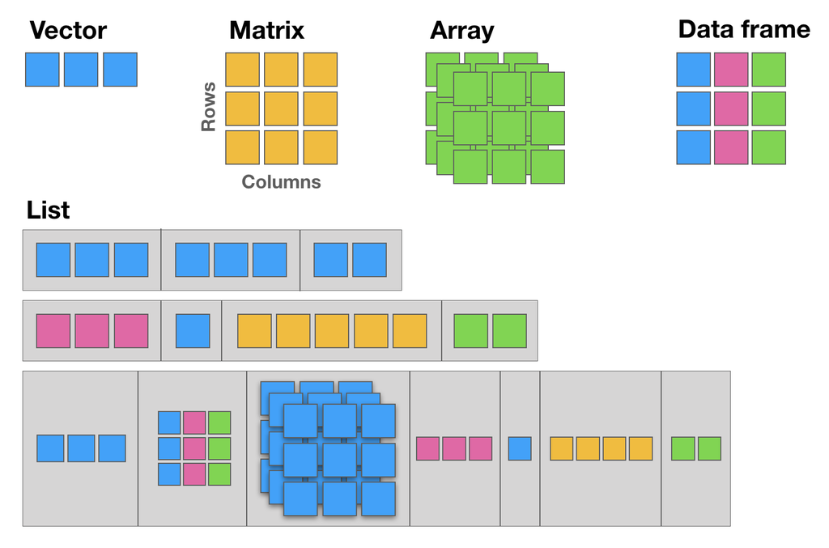

Figure 3: Basic R data structures.

#### 3.1 Vectors

The basic data structure in R is the **vector**, which requires all of its elements to be of the same type (e.g. all numeric; all character (text); all logical (`TRUE` or `FALSE`)).

#### Creating vectors

| Function | Description |
| --- | --- |
| `c` | combine |
| `:` | integer sequence |
| `seq` | general sequence |
| `rep` | repetitive patterns |

```r
x <- c (1,2,3,4,5,6)
x
```

```
[1] 1 2 3 4 5 6
```

```r
class (x)   # this function outputs the class of the object
```

```
[1] "numeric"
```

```r
y <- 10
class (y)
```

```
[1] "numeric"
```

```r
z <- "a string"
class (z)
```

```
[1] "character"
```

```r
# The results are shown in the comments next to each line

seq (1,6)   ## 1 2 3 4 5 6
seq (from=100, by=1, length=5)   ## 100 101 102 103 104

1:6    ## 1 2 3 4 5 6
10:1   ## 10  9  8  7  6  5  4  3  2  1

rep (1:2, 3)   ## 1 2 1 2 1 2
```

#### Vectorized arithmetics

Most arithmetic operations in the R language are **vectorized**, i.e. the operation is applied **element-wise**. When one operand is shorter than the other, the shortest one is **recycled**, i.e. the values from the shorter vector are re-used until the length of the longer vector is reached.  
Please note that when one of the vectors is recycled, a **warning** is printed in the R Console. This warning is **not an error**, i.e. the operation has been completed despite the warning message.

```r
1:3 + 10:12
```

```
[1] 11 13 15
```

```r
# Notice the warning: this is recycling (the shorter vector "restarts" the "cycling")
1:5 + 10:12
```

```
Warning in 1:5 + 10:12: longer object length is not a multiple of shorter
object length
```

```
[1] 11 13 15 14 16
```

```r
x + y         # Remember that x = c(1,2,3,4,5,6) and y = 10
```

```
[1] 11 12 13 14 15 16
```

```r
c(70,80) + x
```

```
[1] 71 82 73 84 75 86
```

#### Subsetting/Indexing vectors

Subsetting is one of the most powerful features of R. It is the extraction of one or more elements, which are of interest, from vectors, allowing for example the filtering of data, the re-ordering of tables, removal of unwanted data-points, etc. There are several ways of sub-setting data.

**Note: Please remember that indices in R are 1-based (see introduction).**

```r
# Subsetting by indices
myVec <- 1:26 ; myVec
myVec [1]    # prints the first value of myVec
myVec [6:9]  # prints the 6th, 7th, 8th, and 9th values of myVec

# LETTERS is a built-in vector with the 26 letters of the alphabet
myLOL <- LETTERS       # assign the 26 letters to the vector named myLOL
myLOL[c(3,3,13,1,18)]  # print the requested positions of vector myLOL

#Subsetting by same length logical vectors
myLogical <- myVec > 10 ; myLogical
# returns only the values in positions corresponding to TRUE in the logical vector
myVec [myLogical]
```

#### Naming indexes of a vector

Referring to an index by name rather than by position can make code more readable and flexible. Use the function *names* to attribute names to each position of the vector.

```r
joe <- c (24, 1.70)
names (joe)              ## NULL
names (joe) <- c ("age","height")
names (joe)              ## "age"    "height"
joe ["age"] == joe [1]   ## age   TRUE

names (myVec) <- LETTERS
myVec
# Subsetting by field names
myVec [c("A", "A", "B", "C", "E", "H", "M")] ## The Fibonacci Series :o)
```

#### Excluding elements

Sometimes we want to retain most elements of a vector, except for one or a few unwanted positions. Instead of specifying all elements of interest, it is easier to specify the ones we want to remove. This is easily done using the **minus sign**.

```r
alphabet <- LETTERS
alphabet   # print vector alphabet
```

```
 [1] "A" "B" "C" "D" "E" "F" "G" "H" "I" "J" "K" "L" "M" "N" "O" "P" "Q" "R" "S"
[20] "T" "U" "V" "W" "X" "Y" "Z"
```

```r
vowel.positions <- c(1,5,9,15,21)
alphabet[vowel.positions]    # print alphabet in vowel.positions
```

```
[1] "A" "E" "I" "O" "U"
```

```r
consonants <- alphabet [-vowel.positions]  # exclude all vowels from the alphabet
consonants
```

```
 [1] "B" "C" "D" "F" "G" "H" "J" "K" "L" "M" "N" "P" "Q" "R" "S" "T" "V" "W" "X"
[20] "Y" "Z"
```

#### 3.2 Matrices

Matrices are two dimensional vectors (tables), where all columns are of the same length, and, just like one-dimensional vectors, matrices store **same-type elements** (e.g. all numeric; all character (text); all logical (`TRUE` or `FALSE`)). Matrices are explicitly created with the `matrix` function.

**IMPORTANT NOTE:** R uses a **column-major order** for the internal linear storage of array values, meaning that first all of column 1 is stored, then all of column 2, etc. This implies that, by default, when you create a matrix, R will populate the first column, then the second, then the third, and so on until all values given to the `matrix` function are used. This is the default behavior of the matrix function, which can be changed via the `byrow` parameter (default value is set to FALSE).

```r
my.matrix <- matrix (1:12, nrow=3, byrow = FALSE)   # byrow = FALSE is the default (see ?matrix)
dim (my.matrix)   # check the dimension (size) of the matrix: number of rows (first number) and number of columns (second number)
my.matrix         # print the matrix

xx <- matrix (1:12, nrow=3, byrow = TRUE)
dim (xx)  # check if the dimensions of xx are the same as the dimensions of my.matrix
xx        # compare my.matrix with xx and make sure you understand what is hapenning
```

#### Subsetting/Indexing matrices

**Very Important Note:** The arguments inside the square brackets in matrices (and data.frames - see next section) are the `[row_number, column_number]`. If any of these is omitted, R assumes that all values are to be used: all rows, if the first value before the comma is missing; or all columns if the second value after the comma is missing.

```r
# Creating a matrix of characters
my.matrix <- matrix (LETTERS, nrow = 4, byrow = TRUE)
# Please notice the warning message (related to the "recycling" of the LETTERS)

my.matrix         # print the matrix
dim (my.matrix)   # check the dimensions of the matrix

# Subsetting by indices
my.matrix [,2]   # all rows, column 2 (returns a vector)
my.matrix [3,]   # row 3, all columns (returns a vector)
my.matrix [1:3,c(4,2)]   # rows 1, 2 and 3 from columns 4 and 2 (by this order) (returns a matrix)
```

#### 3.3 Data frames

Data frames are the most flexible and commonly used R data structures, used to store datasets in spreadsheet-like tables.  
In a `data.frame`, usually the observations are the rows and the variables are the columns. Unlike matrices, the columns of a data frame can be vectors of different types (i.e. text, number, logical, etc, can all be stored in the same data frame). However, each column must to be of the same data type.

```r
df <- data.frame (type=rep(c("case","control"),c(2,3)),time=rnorm(5))
# rnorm is a random number generator retrieved from a normal distribution

class (df)   ## "data.frame"
df
```